# Bot

```python
import numpy as np
import pandas as pd
from matplotlib import pyplot as plt
from datetime import datetime
from scipy.stats import spearmanr
from sklearn.preprocessing import LabelEncoder
```

### Грузим данные. Они уже отфильтрованы (одна запись от пользователя в сутки, пустые удалены). Заодно спрячем пользовательские id из телеграма.

```python
df = pd.read_csv('results.csv')
le = LabelEncoder()
df['user_id'] = le.fit_transform(df['user_id'])
df
```

|  | Unnamed: 0 | user_id | date | sex | timezone | age | city | occupation | question_time_minutes | white | ... | purple | pink | lightskyblue | beige | saddlebrown | orchid | maroon | mediumturquoise | coral | greenyellow |
| --- | --- | --- | --- | --- | --- | --- | --- | --- | --- | --- | --- | --- | --- | --- | --- | --- | --- | --- | --- | --- | --- |
| 0 | 0 | 93 | 2021-04-13 12:31:07.731 | female | 3 | 28.0 | Спб | worker | 1320.0 | 0 | ... | 1 | 0 | 0 | 0 | 0 | 0 | 0 | 0 | 0 | 0 |
| 1 | 1 | 93 | 2021-04-14 04:37:16.818 | female | 3 | 28.0 | Спб | worker | 1320.0 | 1 | ... | 0 | 0 | 0 | 0 | 0 | 0 | 0 | 0 | 0 | 0 |
| 2 | 2 | 93 | 2021-04-15 08:01:14.953 | female | 3 | 28.0 | Спб | worker | 1320.0 | 0 | ... | 0 | 0 | 0 | 0 | 0 | 0 | 0 | 0 | 0 | 0 |
| 3 | 3 | 93 | 2021-04-16 22:34:46.480 | female | 3 | 28.0 | Спб | worker | 1320.0 | 0 | ... | 0 | 0 | 0 | 0 | 0 | 1 | 0 | 0 | 0 | 0 |
| 4 | 4 | 93 | 2021-04-17 18:53:59.683 | female | 3 | 28.0 | Спб | worker | 1320.0 | 0 | ... | 0 | 0 | 0 | 0 | 0 | 0 | 0 | 0 | 0 | 0 |
| ... | ... | ... | ... | ... | ... | ... | ... | ... | ... | ... | ... | ... | ... | ... | ... | ... | ... | ... | ... | ... | ... |
| 2343 | 2343 | 57 | 2021-05-16 18:03:51.737 | female | 3 | 30.0 | Санкт-Петербург | worker | 1240.0 | 0 | ... | 0 | 1 | 0 | 1 | 0 | 0 | 0 | 0 | 0 | 0 |
| 2344 | 2344 | 57 | 2021-05-17 17:41:11.994 | female | 3 | 30.0 | Санкт-Петербург | worker | 1240.0 | 0 | ... | 0 | 1 | 0 | 1 | 1 | 0 | 0 | 0 | 0 | 0 |
| 2345 | 2345 | 96 | 2021-05-14 10:07:32.625 | female | 3 | 32.0 | Санкт-Петербург | worker | 780.0 | 0 | ... | 0 | 0 | 1 | 0 | 0 | 0 | 1 | 0 | 0 | 0 |
| 2346 | 2346 | 96 | 2021-05-15 10:15:23.421 | female | 3 | 32.0 | Санкт-Петербург | worker | 780.0 | 0 | ... | 0 | 1 | 1 | 0 | 0 | 0 | 1 | 0 | 0 | 0 |
| 2347 | 2347 | 96 | 2021-05-16 21:04:26.019 | female | 3 | 32.0 | Санкт-Петербург | worker | 780.0 | 1 | ... | 0 | 0 | 0 | 0 | 0 | 0 | 0 | 0 | 0 | 0 |

2348 rows × 27 columns

```python
df.info()
```

```
<class 'pandas.core.frame.DataFrame'>
RangeIndex: 2348 entries, 0 to 2347
Data columns (total 27 columns):
 #   Column                 Non-Null Count  Dtype
---  ------                 --------------  -----
 0   Unnamed: 0             2348 non-null   int64
 1   user_id                2348 non-null   int64
 2   date                   2348 non-null   object
 3   sex                    2345 non-null   object
 4   timezone               2348 non-null   int64
 5   age                    2338 non-null   float64
 6   city                   2345 non-null   object
 7   occupation             2338 non-null   object
 8   question_time_minutes  2338 non-null   float64
 9   white                  2348 non-null   int64
```

[output cut: 19 more lines]

```python
df['city'].unique()
```

```
array(['Спб', 'Санкт-Петербург', nan, 'Москва', 'С-Пб', 'СПб', 'Berlin',
       '/send_colors', 'Петербург', 'Новосибирск', 'москва', 'Питер',
       'спб', 'Екатеринбург', 'Севастополь', 'санкт-петербург',
       'Санкт-Петербурга', 'Уппсала', 'Копенгаген', 'Дармштадт',
       'Мурманск', 'Чанчунь', 'Омск'], dtype=object)
```

### Немного чиним данные

```python
def get_occupation(x):
    if x == 'kid':
        return 0
    if x == 'student':
        return 1
    if x == 'worker':
        return 2
    if x == 'retiree':
        return 3
    return 4


def get_city(city):
    if type(city) != str:
        return 'unknown'
    if city in [ 'Петербург',
                 'петербург',
                 'Питер',
                 'питер'
                 'С-Пб',
                 'СПб',
                 'спб',
                 'с-пб',
                 'Санкт-Петербург',
                 'Санкт-Петербурга',
                 'Спб',
                 'санкт-петербург',
                 'спб' ]:
        return 'spb'
    if city.lower() in ['москва', 'moskow']:
        return 'msk'
    if city.lower() == 'екатеринбург':
        return 'ekb'
    if city.lower() == 'новосибирск':
        return 'nsk'
    if city.lower() == 'севастополь':
        return 'sev'
    return 'other'


def get_weekday(year, month, day):
    return datetime(year=year, month=month, day=day).weekday()

def get_day_number(year, month, day):
    delta = datetime(year=year, month=month, day=day) - datetime(year=2021, month=4, day=1)
    return delta.days


# удаляем индекс
df = df.drop('Unnamed: 0', axis=1)

# строим по дате признаки (а она у нас в виде строки изначально)
df['year'] = [int(x[:4]) for x in df['date']]
df['month'] = [int(x[5:7]) for x in df['date']]
df['day'] = [int(x[8:10]) for x in df['date']]
df['day_number'] = [get_day_number(int(x[:4]), int(x[5:7]), int(x[8:10])) for x in df['date']]
df['weekday'] = [get_weekday(int(x[:4]), int(x[5:7]), int(x[8:10])) for x in df['date']]
df = df.drop('date', axis=1)

# считаем, что неизвестная временная зона - это +3
df['timezone'].fillna(3, inplace=True)

# заполняем неизвестный род занятий
df['occupation'].fillna('unknown', inplace=True)

# и неизвестный пол
df['sex'].fillna('unknown', inplace=True)

# стандартизируем город
df['city'] = [get_city(x) for x in df['city']]

# заполняем пропуски
df.fillna(df.median(), inplace=True)

# смотрим, что все хорошо заполнилось
df.info()
```

```
<class 'pandas.core.frame.DataFrame'>
RangeIndex: 2348 entries, 0 to 2347
Data columns (total 30 columns):
 #   Column                 Non-Null Count  Dtype
---  ------                 --------------  -----
 0   user_id                2348 non-null   int64
 1   sex                    2348 non-null   object
 2   timezone               2348 non-null   int64
 3   age                    2348 non-null   float64
 4   city                   2348 non-null   object
 5   occupation             2348 non-null   object
 6   question_time_minutes  2348 non-null   float64
 7   white                  2348 non-null   int64
 8   gray                   2348 non-null   int64
 9   black                  2348 non-null   int64
```

[output cut: 22 more lines]

```python
df
```

|  | user_id | sex | timezone | age | city | occupation | question_time_minutes | white | gray | black | ... | orchid | maroon | mediumturquoise | coral | greenyellow | year | month | day | day_number | weekday |
| --- | --- | --- | --- | --- | --- | --- | --- | --- | --- | --- | --- | --- | --- | --- | --- | --- | --- | --- | --- | --- | --- |
| 0 | 93 | female | 3 | 28.0 | spb | worker | 1320.0 | 0 | 0 | 1 | ... | 0 | 0 | 0 | 0 | 0 | 2021 | 4 | 13 | 12 | 1 |
| 1 | 93 | female | 3 | 28.0 | spb | worker | 1320.0 | 1 | 0 | 1 | ... | 0 | 0 | 0 | 0 | 0 | 2021 | 4 | 14 | 13 | 2 |
| 2 | 93 | female | 3 | 28.0 | spb | worker | 1320.0 | 0 | 1 | 1 | ... | 0 | 0 | 0 | 0 | 0 | 2021 | 4 | 15 | 14 | 3 |
| 3 | 93 | female | 3 | 28.0 | spb | worker | 1320.0 | 0 | 0 | 0 | ... | 1 | 0 | 0 | 0 | 0 | 2021 | 4 | 16 | 15 | 4 |
| 4 | 93 | female | 3 | 28.0 | spb | worker | 1320.0 | 0 | 0 | 1 | ... | 0 | 0 | 0 | 0 | 0 | 2021 | 4 | 17 | 16 | 5 |
| ... | ... | ... | ... | ... | ... | ... | ... | ... | ... | ... | ... | ... | ... | ... | ... | ... | ... | ... | ... | ... | ... |
| 2343 | 57 | female | 3 | 30.0 | spb | worker | 1240.0 | 0 | 0 | 1 | ... | 0 | 0 | 0 | 0 | 0 | 2021 | 5 | 16 | 45 | 6 |
| 2344 | 57 | female | 3 | 30.0 | spb | worker | 1240.0 | 0 | 0 | 0 | ... | 0 | 0 | 0 | 0 | 0 | 2021 | 5 | 17 | 46 | 0 |
| 2345 | 96 | female | 3 | 32.0 | spb | worker | 780.0 | 0 | 0 | 0 | ... | 0 | 1 | 0 | 0 | 0 | 2021 | 5 | 14 | 43 | 4 |
| 2346 | 96 | female | 3 | 32.0 | spb | worker | 780.0 | 0 | 0 | 0 | ... | 0 | 1 | 0 | 0 | 0 | 2021 | 5 | 15 | 44 | 5 |
| 2347 | 96 | female | 3 | 32.0 | spb | worker | 780.0 | 1 | 0 | 1 | ... | 0 | 0 | 0 | 0 | 0 | 2021 | 5 | 16 | 45 | 6 |

2348 rows × 30 columns

### Всего у нас 2348 уникальных записи. Посмотрим на данные (распределение разных признаков по записям и по людям). Для начала создадим новый датафрейм с информацией о каждом пользователе

```python
person_features = ['user_id', 'sex', 'timezone', 'age', 'city', 'occupation']
colors = ['white', 'gray', 'black', 'red', 'blue', 'yellow', 'green', 'orange', 'purple', 'pink', 'lightskyblue', 'beige',
          'saddlebrown', 'orchid', 'maroon', 'mediumturquoise', 'coral', 'greenyellow']
```

```python
df_persons = df[person_features].groupby('user_id').agg(pd.Series.mode)
df_persons
```

| user_id | sex | timezone | age | city | occupation |
| --- | --- | --- | --- | --- | --- |
| 0 | female | 3 | 28.0 | spb | worker |
| 1 | female | 3 | 34.0 | spb | worker |
| 2 | male | 3 | 29.0 | spb | worker |
| 3 | female | 3 | 30.0 | spb | worker |
| 4 | male | 3 | 30.0 | spb | worker |
| ... | ... | ... | ... | ... | ... |
| 123 | female | 8 | 34.0 | other | worker |
| 124 | female | 3 | 22.0 | spb | worker |
| 125 | male | 3 | 33.0 | spb | worker |
| 126 | female | 3 | 77.0 | spb | retiree |
| 127 | female | 3 | 38.0 | spb | worker |

128 rows × 5 columns

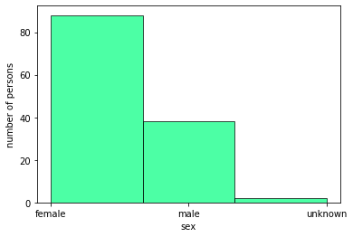

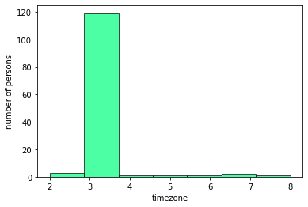

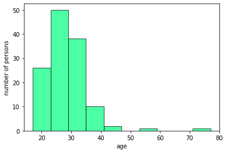

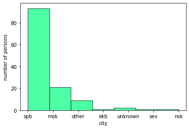

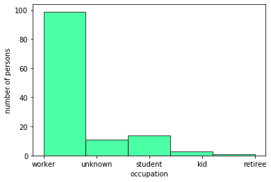

```python
for feature in ['sex', 'timezone', 'age', 'city', 'occupation']:
    plt.hist(df_persons[feature], bins=min(len(df_persons[feature].unique()), 10), edgecolor='black', alpha=0.7, color='springgreen')
    plt.xlabel(feature)
    plt.ylabel('number of persons')
    plt.show()
```

### По записям также посмотрим на день недели, день с начала существования бота и так далее

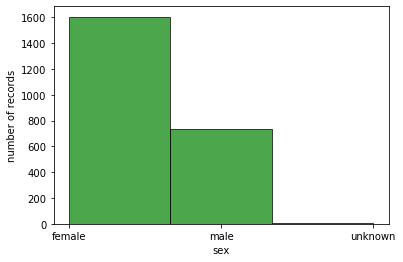

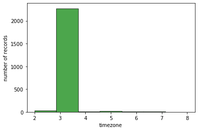

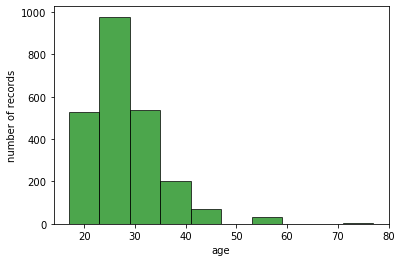

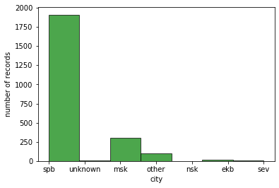

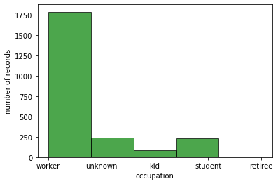

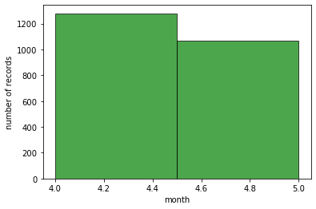

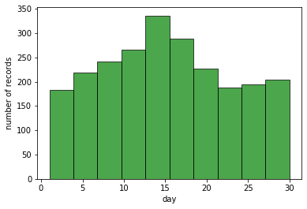

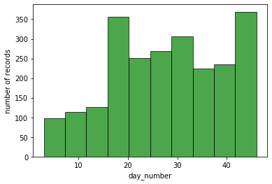

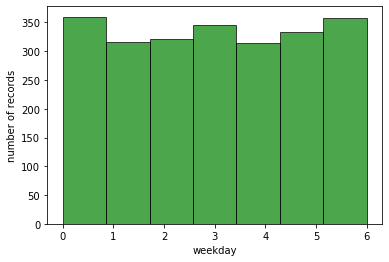

```python
for feature in ['sex', 'timezone', 'age', 'city', 'occupation', 'month', 'day', 'day_number', 'weekday']:
    plt.hist(df[feature], bins=min(len(df[feature].unique()), 10), edgecolor='black', alpha=0.7, color='green')
    plt.xlabel(feature)
    plt.ylabel('number of records')
    plt.show()
```

### Для красоты посмотрим еще на общий графи распределения цветов по дням

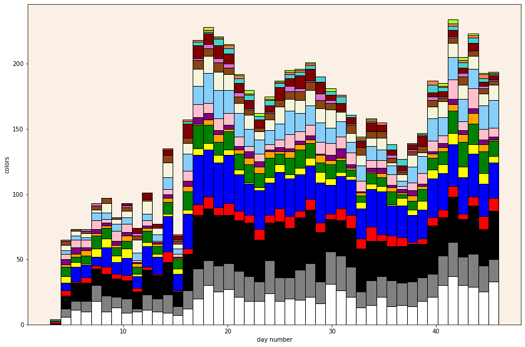

```python
bins = len(df['day_number'].unique())

fig = plt.figure(figsize=(15, 10))
ax = fig.add_subplot(111)
ax.set_facecolor('linen')
plt.hist([df[df[color] == 1]['day_number'] for color in colors],
         bins=bins,
         stacked=True,
         color=colors,
         edgecolor='black')
plt.xlabel('day number')
plt.ylabel('colors')

plt.show()
```

### Создадим еще один датафрейм, где каждому человеку будем сопоставлять частоту ношения им каждого цвета (от 0 до 1, 0 - не носит никогда, 0.5 - через день, 1.0 - ежедневно)

```python
df_freqs = df.groupby('user_id').sum()[colors] / df.groupby('user_id').count()[colors]
df_freqs = df_freqs.merge(df_persons, on=['user_id'])
df_freqs
```

| user_id | white | gray | black | red | blue | yellow | green | orange | purple | pink | ... | orchid | maroon | mediumturquoise | coral | greenyellow | sex | timezone | age | city | occupation |
| --- | --- | --- | --- | --- | --- | --- | --- | --- | --- | --- | --- | --- | --- | --- | --- | --- | --- | --- | --- | --- | --- |
| 0 | 0.142857 | 0.642857 | 0.785714 | 0.071429 | 0.357143 | 0.000000 | 0.000000 | 0.000000 | 0.285714 | 0.214286 | ... | 0.00000 | 0.000000 | 0.285714 | 0.071429 | 0.00000 | female | 3 | 28.0 | spb | worker |
| 1 | 0.333333 | 0.500000 | 0.333333 | 0.000000 | 0.500000 | 0.333333 | 0.333333 | 0.000000 | 0.000000 | 0.000000 | ... | 0.00000 | 0.166667 | 0.000000 | 0.000000 | 0.00000 | female | 3 | 34.0 | spb | worker |
| 2 | 0.514286 | 0.285714 | 0.314286 | 0.085714 | 0.828571 | 0.085714 | 0.000000 | 0.000000 | 0.000000 | 0.028571 | ... | 0.00000 | 0.000000 | 0.000000 | 0.028571 | 0.00000 | male | 3 | 29.0 | spb | worker |
| 3 | 0.200000 | 0.133333 | 0.333333 | 0.133333 | 0.333333 | 0.000000 | 0.266667 | 0.000000 | 0.200000 | 0.066667 | ... | 0.00000 | 0.000000 | 0.000000 | 0.000000 | 0.00000 | female | 3 | 30.0 | spb | worker |
| 4 | 0.000000 | 0.133333 | 0.833333 | 0.400000 | 0.666667 | 0.000000 | 0.033333 | 0.000000 | 0.000000 | 0.000000 | ... | 0.00000 | 0.566667 | 0.000000 | 0.000000 | 0.00000 | male | 3 | 30.0 | spb | worker |
| ... | ... | ... | ... | ... | ... | ... | ... | ... | ... | ... | ... | ... | ... | ... | ... | ... | ... | ... | ... | ... | ... |
| 123 | 0.000000 | 0.500000 | 0.000000 | 0.000000 | 1.000000 | 0.000000 | 0.000000 | 0.500000 | 0.000000 | 0.500000 | ... | 0.00000 | 0.500000 | 0.000000 | 0.000000 | 0.00000 | female | 8 | 34.0 | other | worker |
| 124 | 0.343750 | 0.531250 | 0.843750 | 0.000000 | 0.062500 | 0.031250 | 0.125000 | 0.031250 | 0.031250 | 0.125000 | ... | 0.00000 | 0.093750 | 0.000000 | 0.000000 | 0.15625 | female | 3 | 22.0 | spb | worker |
| 125 | 0.516129 | 0.870968 | 0.419355 | 0.129032 | 0.096774 | 0.096774 | 1.000000 | 0.032258 | 0.000000 | 0.161290 | ... | 0.00000 | 0.000000 | 0.000000 | 0.000000 | 0.00000 | male | 3 | 33.0 | spb | worker |
| 126 | 1.000000 | 0.666667 | 0.333333 | 0.000000 | 0.000000 | 0.000000 | 1.000000 | 0.000000 | 0.333333 | 0.000000 | ... | 0.00000 | 0.000000 | 0.000000 | 0.000000 | 0.00000 | female | 3 | 77.0 | spb | retiree |
| 127 | 0.354839 | 0.225806 | 0.645161 | 0.096774 | 0.645161 | 0.161290 | 0.419355 | 0.032258 | 0.032258 | 0.064516 | ... | 0.16129 | 0.000000 | 0.032258 | 0.000000 | 0.00000 | female | 3 | 38.0 | spb | worker |

128 rows × 23 columns

### Для каждого цвета посмотрим на количество пользователей, которые его не надевали ни разу.

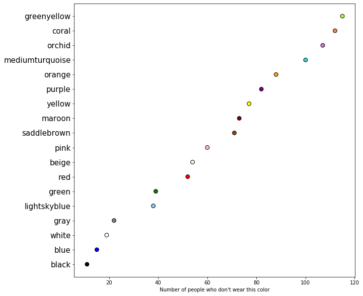

```python
color_lovers = [(np.sum(df_freqs[color] == 0), color) for color in colors]
color_lovers.sort(key=lambda x: x[0])

fig, ax = plt.subplots(figsize=(10, 10))
ax.scatter([x[0] for x in color_lovers], [x[1] for x in color_lovers], color=[x[1] for x in color_lovers], edgecolor='black', s=60)
ax.set_yticklabels([x[1] for x in color_lovers],
                   fontsize = 15)
plt.xlabel("Number of people who don't wear this color")
plt.show()
```

```python
print('Минимальное количество не носивших:', color_lovers[0][0], color_lovers[0][1])
print('Мaксимальное количество не носивших:', color_lovers[-1][0], color_lovers[-1][1])
```

```
Минимальное количество не носивших: 11 black
Мaксимальное количество не носивших: 115 greenyellow
```

### Исследуем связь пола и цвета. Для начала разделим мужчин и женщин и посмотрим с помощью непараметрического теста Манна-Уитни, одинаково ли они выбирают цвета

```python
df_males = df_freqs[df_freqs['sex'] == 'male'].drop('sex', axis=1)
df_females = df_freqs[df_freqs['sex'] == 'female'].drop('sex', axis=1)

df_males.shape
```

```
(38, 22)
```

```python
df_females.shape
```

```
(88, 22)
```

### Посмотрим на нормированные гистограммы частот ношения цветов

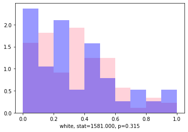

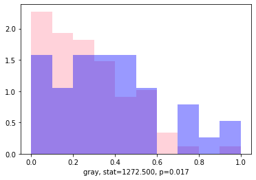

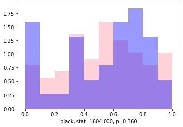

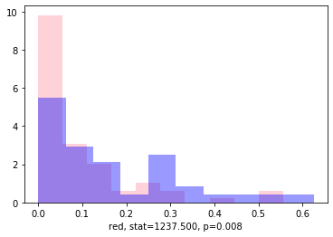

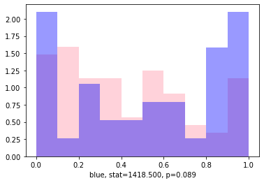

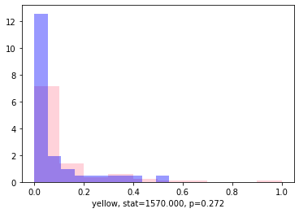

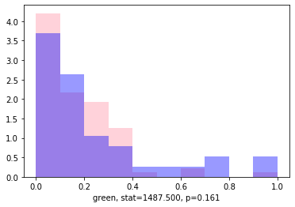

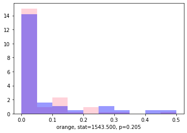

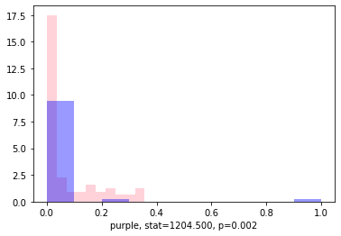

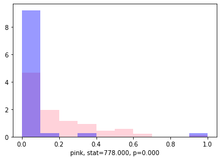

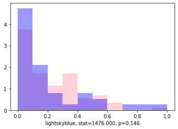

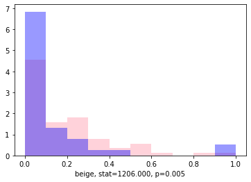

[6 more figures not shown]

```python
from scipy.stats import mannwhitneyu

color_diffs = []
alpha = 0.05

for color in colors:
    plt.hist(df_females[color], alpha=0.7, color='pink', bins=10, density=True)
    plt.hist(df_males[color], alpha=0.4, color='blue', bins=10, density=True)
    stat, p = mannwhitneyu(df_females[color], df_males[color])
    color_diffs.append((color, stat, p))
    plt.xlabel(color + ', ' + 'stat=%.3f, p=%.3f' % (stat, p))
    plt.show()
```

```
coral           : stat = 1671.500, p = 0.500
black           : stat = 1604.000, p = 0.360
saddlebrown     : stat = 1590.500, p = 0.319
white           : stat = 1581.000, p = 0.315
yellow          : stat = 1570.000, p = 0.272
orange          : stat = 1543.500, p = 0.205
green           : stat = 1487.500, p = 0.161
lightskyblue    : stat = 1476.000, p = 0.146
greenyellow     : stat = 1554.000, p = 0.118
blue            : stat = 1418.500, p = 0.089
maroon          : stat = 1378.000, p = 0.043
gray            : stat = 1272.500, p = 0.017
orchid          : stat = 1382.500, p = 0.009
red             : stat = 1237.500, p = 0.008
beige           : stat = 1206.000, p = 0.005
mediumturquoise : stat = 1279.500, p = 0.002
purple          : stat = 1204.500, p = 0.002
pink            : stat = 778.000, p = 0.000
```

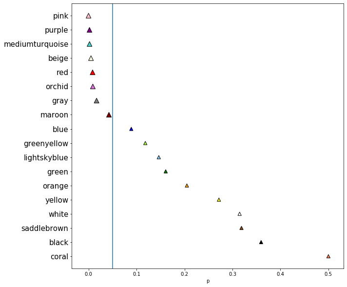

```python
color_diffs.sort(key=lambda x: -x[2])


for record in color_diffs:
    print(f'{record[0]:<16}: stat = %.3f, p = %.3f' % (record[1], record[2]))

fig, ax = plt.subplots(figsize=(10, 10))
ax.scatter([record[2] for record in color_diffs],
           [record[0] for record in color_diffs],
           edgecolor='black',
           color=[x[0] for x in color_diffs],
           marker='^',
           s=[100 if x[2] < alpha else 50 for x in color_diffs])
ax.axvline(x=alpha)
ax.set_yticklabels([x[0] for x in color_diffs],
                   fontsize = 15)
plt.xlabel('p')
plt.show()
```